# tmp9dw32ai4

## 思想剧场：人性辩论赛开幕！

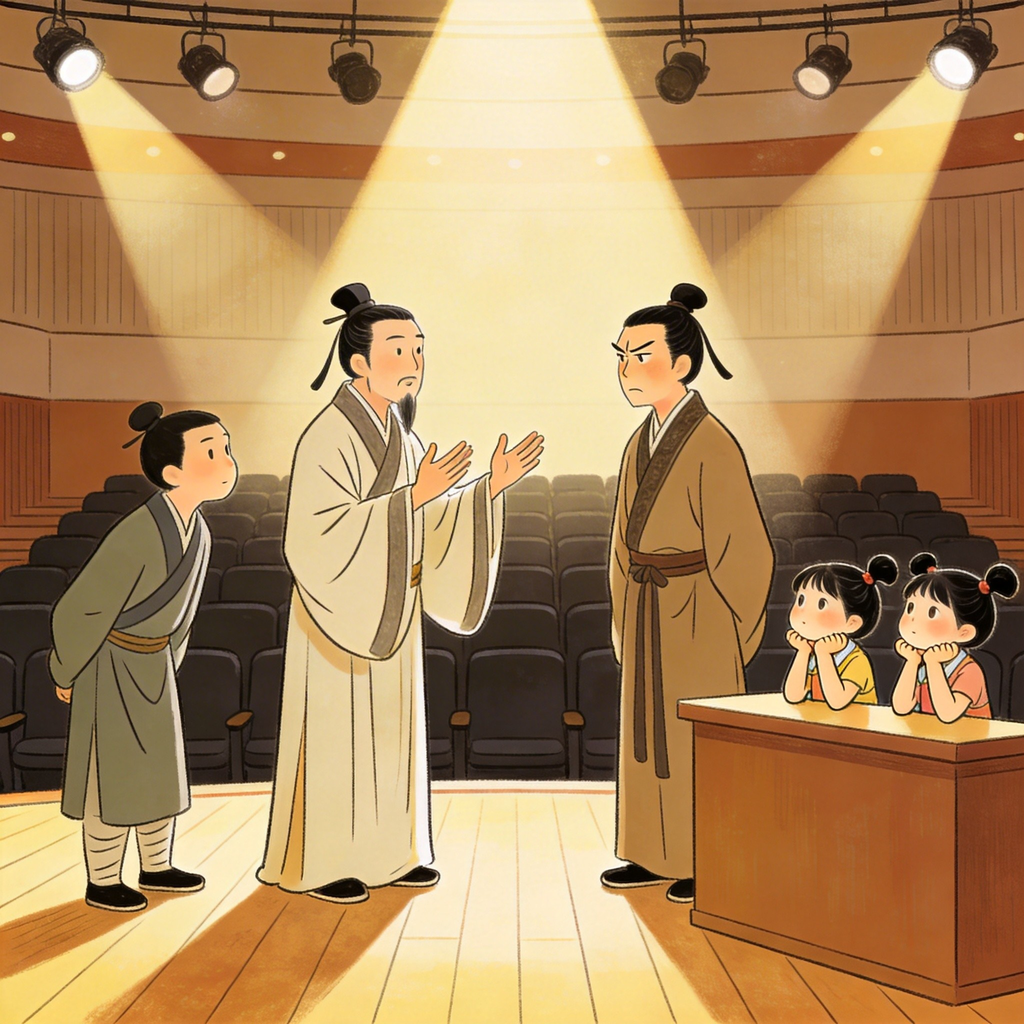

## 第一站：孟子的“四端说”——心里的四颗好种子🌟

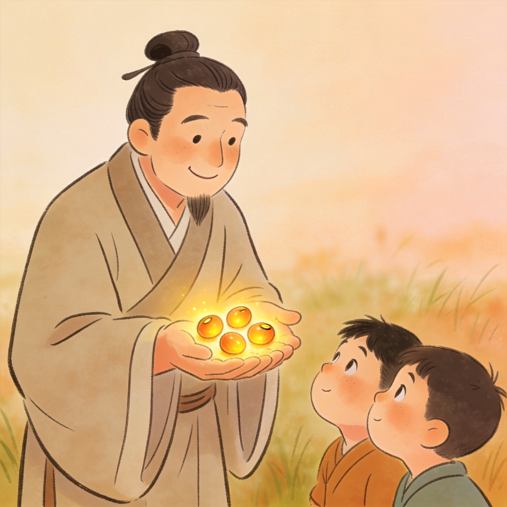

## 第二站：告子的“白板说”——空白的画板🌟

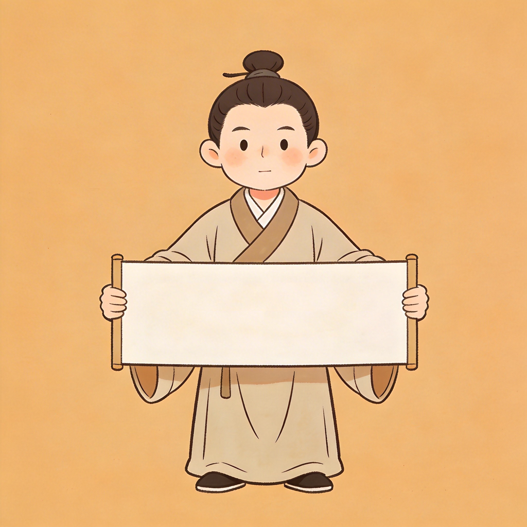

## 第三站：荀子的“性恶论”——未经打磨的玉石🌟

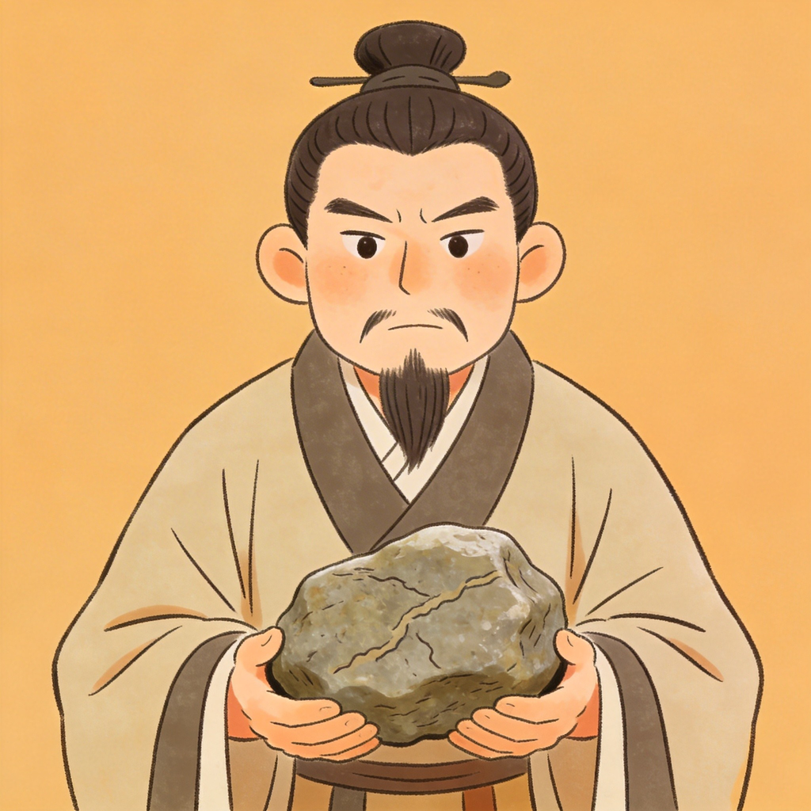

# 第二章 为什么我和别人不一样？

**时间**：周五下午社团活动时间  
**地点**：学校小礼堂辩论角  
**人物**：小星（10岁，爱问“为什么”的女孩）、小宇（11岁，喜欢编程的男孩）、三位古代辩手 （幕起） 小星和小宇站在辩论台一侧，台下坐着好奇的同学们。黑板上写着今天的辩题：

**“人性本善 vs 人性本恶 vs 人性空白”** **小星**：（深吸一口气）今天我们要当裁判，评断三位古代思想家的观点！

**小宇**：（推了推眼镜）规则是：每人5分钟陈述，然后我们提问，最后观众投票。 （礼堂灯光暗下，三束聚光灯分别照亮三个入场口）

**第一束光**：孟子（约公元前372-289）缓步上台，手持四颗发光的种子，笑容温和而坚定。

**第二束光**：告子（战国中期）拿着一块空白画板，表情务实冷静。

**第三束光**：荀子（约公元前313-238）举着一块未经雕琢的玉石，神情严肃认真。

**三人齐声**：我们来告诉你——为什么你和别人不一样！

**小星的即兴提问**：（举手）等等！你们三位相差几百年，怎么今天凑一起了？

**孟子**：（点头）

**能**——只要你们愿意倾听对方，而不是只想赢。辩论不是吵架，是共同寻找答案的旅程。 **小宇的笔记**：第一回合开始——人性本质大揭秘！ — ### 古人说

**原文**： > “所以谓人皆有不忍人之心者，今人乍见孺子将入于井，皆有怵惕恻隐之心。” > Suǒyǐ wèi rén jiē yǒu bù rěn rén zhī xīn zhě, jīn rén zhà jiàn rúzi jiāng rù yú jǐng, jiē yǒu chùtì cèyǐn zhī xīn.

**字词解释**： -

**不忍人之心**：不忍心看到别人受苦的心。 -

**乍见**：突然看见。 -

**孺子**：小孩子。 -

**怵惕恻隐**：惊吓、恐惧、同情、怜悯。

**趣味比喻**： 孟子说，每个人的心里都有

**四颗好种子**（四端）： 1. **恻隐之心**——仁的种子：看到别人痛苦，你心里会不舒服。 2. **羞恶之心**——义的种子：自己做错事，会脸红、会后悔。 3. **辞让之心**——礼的种子：自然想让长辈先走、让朋友先玩。 4. **是非之心**——智的种子：天然知道什么是对、什么是错。 **生活案例**： > 学校操场上，小明跑步时摔倒了，膝盖擦破流血。你的第一反应是什么？ > - A. 立刻跑过去扶他（恻隐之心在发芽） > - B. 先想“他是不是装的？”（怀疑盖住了种子） > - C. 假装没看见，继续打球（种子被泥土埋住了）

**小星的辩论回合**：孟老师，可是我真的经常嫉妒同学考得好啊！这也能算“善种子”吗？

**孟子**：问得好！嫉妒是

**后天的习气**，就像好种子被泥土盖住了。但种子本身还在——你会因为嫉妒而内心挣扎，这说明你的“是非之心”还在工作。 **小宇的追问**：那如果有人完全没有四端——天生坏蛋，怎么办？

**孟子**：**不可能**。四端就像人都有四肢一样天然具备。只是有人被“泥土”（坏习惯、错误教育）盖得太厚，暂时看不见。但只要愿意，谁都能“擦亮镜子”。 **小星的立场选择**：（举手）我觉得孟子说得对！就像我上次看到小猫咪卡在树上，虽然害怕，还是找大人来救它——这应该就是恻隐之心的种子在发芽！我支持孟子！

**小宇的立场选择**：（推眼镜）但我有点犹豫……如果真的有人天生坏蛋呢？我先保留意见，听完告子和荀子再说。 —

### 古人说

**原文**（通过孟子记载）： > “性犹杞柳也，义犹杯棬也；以人性为仁义，犹以杞柳为杯棬。” > Xìng yóu qǐliǔ yě, yì yóu bēiquān yě; yǐ rénxìng wéi rényì, yóu yǐ qǐliǔ wéi bēiquān. **字词解释**： -

**杞柳**：一种柔软的柳树，可编织器物。 -

**杯棬**：用杞柳编织的杯子。 -

**比喻**：人性像杞柳（原材料），仁义像编好的杯子（成品）。

**趣味比喻**： 告子说，人出生时就像一块

**空白的画板**。上面画什么，取决于谁拿画笔、用什么颜料（环境输入）。 **三种画笔**： 1.

**家庭画笔**：父母的教育方式、家庭氛围。 2.

**学校画笔**：老师的引导、同学的互动。 3.

**社会画笔**：媒体信息、文化价值观。

**生活案例**： > 双胞胎小花和小草，出生后分开抚养： > - 小花在音乐世家长大→自然爱弹钢琴 > - 小草在体育教练家庭→自然爱跑步 > > 同样的“原材料”，不同的“画作”。

**儿童生活共鸣点**：想想你在学校的经历——如果班上同学都在玩一种新游戏，你也会想学；如果大家都嘲笑某个同学，你可能也不敢和他玩。这就是“环境画笔”在悄悄作画！你的很多选择，其实是被周围的气氛“编程”出来的。

**小星的反驳**：告老师，那我们的“自我选择”呢？难道我只是环境的复印机？

**告子**：**选择本身也是环境塑造的**。你以为“自己选”的爱好，其实是你接触过的信息、见过的人、读过的书共同“编程”的结果。 **小宇的追问**：那改变的关键是什么？

**告子**：**换画笔、换颜料、换画布**。如果你不满意现在的自己——换朋友圈、换信息源、换生活环境。你是**可重写的程序**，不是**固定的硬件**。 **小星的立场选择**：告老师的观点让我有点难过……如果我只是环境的产物，那我的努力还有什么意义？我暂时不支持这个观点，等听完荀子再说。

**小宇的立场选择**：我觉得告子说得有道理！就像我学编程是因为爸爸是程序员，如果我生在画家家庭，可能就在学画画了。环境确实很重要！ —

### 古人说

**原文**： > “人之性恶，其善者伪也。” > Rén zhī xìng è, qí shàn zhě wěi yě.

**字词解释**： -

**性**：天生的本性。 -

**恶**：不是“邪恶”，而是

**自私、贪图享受、好利**的自然倾向。 - **伪**：不是“虚假”，而是

**人为努力、后天改造**。 **趣味比喻**： 荀子说，人天生是

**未经打磨的玉石**。天然有杂质、不完美，但经过雕刻（学习、练习）可以变成艺术品。 **化性起伪三步法**🌟： 1. **承认性恶**：诚实面对“我就是想偷懒/占便宜/嫉妒”。 2.

**用礼义约束**：学习社会规则，模仿好榜样，刻意练习。 3.

**积累成习惯**：练习次数多了，“恶”的倾向就弱了，“善”的习惯就形成了。

**生活案例**： > 周一早晨，闹钟响了： > -

**天性反应**：关掉闹钟，继续睡（“性恶”——贪图舒适） > -

**化性起伪**：想起“今日事今日毕”的承诺，咬牙起床（“伪”——人为努力） > > 坚持21天后，早起变成

**自然习惯**——你已经把玉石打磨出了一角。 **儿童生活共鸣点**：就像你明明知道该写作业，却总想玩手机；明明知道该分享玩具，却舍不得。这些“小天性”需要你像锻炼肌肉一样每天练习克服。荀子的“化性起伪”就是你的

**天性健身房**！ **小星的质疑**：荀老师，您把人性说得太悲观了吧？我觉得自己挺善良的啊！

**荀子**：（严肃）

**善良是努力的结果，不是天生的礼物**。你看到有人慷慨——那是他练习出来的。你看到有人自律——那是他战胜了自己的懒。**人的伟大，恰恰在于能改造天性**。 **小宇的总结**：所以孟子的“善种子”是潜力，荀子的“恶玉石”是起点，告子的“白板”是画布——三合一才完整？

**荀子**：正是！三家合观，才是完整的人性地图。 —

## 想一想（互动升级版）

请拿出笔，在书上空白处写下你的真实想法——没有标准答案，只有你的探险笔记！

**当中国古人在辩论“性善性恶”时，世界其他地方在想什么？**

**自我打磨**（像玉石雕刻），基督教认为人性需**外部救赎**（像病人求医）。一个强调人的主动性，一个强调神的恩典。 **差异说明**： 这与东西方世界观有关：中国思想多强调“人可通过修养成为圣人”，西方宗教多强调“人需依靠超越性力量”。就像学骑车——中国思想鼓励你“多练就会”，基督教思想提醒你“需要父母扶一把”。

**思考题**： 你觉得“靠自己的力量变好”更鼓舞人，还是“有更高的力量帮助你”更安心？试分析你的选择背后的文化影响。 【视觉建议】 -

**简笔画地图**：一张东西方对比地图，左侧画中国荀子手拿凿子雕刻玉石，右侧画十字架下伸手拯救的意象，中间用虚线箭头连接，标注“自力 vs 他力”。 -

**人物剪影**：孟子与柏拉图侧影并列，孟子身边画发芽的种子，柏拉图身边画马车与缰绳。 — ## 实践练习：2章主题实践（可操作增强版）

**初级（观察员）**：家长作为“人性观察员”，记录孩子本周的“四端表现”，周末分享发现。 -

**中级（实验伙伴）**：家长和孩子各自选择一个“天性”进行改造，互相监督，每日打卡。 -

**高级（家庭人性研讨会）**：周末召开家庭会议，讨论： 1. 我们家每个人的“人性特点”是什么？ 2. 家庭环境如何塑造我们？ 3. 我们可以共同改造哪些“家庭天性”？

**基本要求**： 1. 每周至少完成3次观察记录 2. 周末写一段总结反思（至少100字） 3. 尝试将哲学概念与生活经验联系起来 — — ## 智慧探险地图碎片 #2（升级版）

```
┌─────────────────────────────────────────────┐
│  第二章：为什么我和别人不一样？            │
├─────────────────────────────────────────────┤
│  🧭 探索路径                                │
│  • 从内在潜能（孟）→ 环境塑造（告）→ 后天改造（荀） │
│  • 关键问题：人性是固定的，还是可塑的？      │
├─────────────────────────────────────────────┤
│  👴 遇见智者                                │
│  • 孟子——性善（心里有四颗好种子🌟）        │
│  • 告子——白板说（空白的画板🌟）             │
│  • 荀子——性恶论（未经打磨的玉石🌟）         │
│       → 化性起伪（把野马驯成赛马🌟）        │
├─────────────────────────────────────────────┤
│  🛠️ 思想工具（带走这三个）                  │
│  1. “四端探测器”                            │
│     • 每天记录1次恻隐、羞恶、辞让、是非时刻  │
│     • 发现你最常/最少出现的“善种子”         │
│  2. “环境画笔检查表”                        │
│     • 分析：家庭、学校、朋友、媒体各画了什么？│
│     • 行动：如果不满，换画笔还是换颜料？     │
│  3. “化性起伪挑战计划”                      │
│     • 选择1个顽固天性                        │
│     • 设计21天对抗策略                      │
│     • 记录成功/失败，分析原因               │
├─────────────────────────────────────────────┤
│  ❓ 留下你的问题（写在书边空白处）          │
│  • “如果三家都对，我到底该信哪个？”          │
│  • “环境决定一切，那我的自由意志在哪里？”    │
│  • “改造天性的努力，会不会也是一种天性？”    │
└─────────────────────────────────────────────┘
```

## 下一章预告（悬念版）

**第三章：怎样才算“赢了”？**  
我们将进入**道家与兵家的智慧竞技场**： -

**庄子**说：真正的赢，是“不争而胜”，像风一样自由！ - **惠施**说：赢在逻辑，先把“赢”的定义搞清楚！ - **孙子**说：赢在策略，“不战而屈人之兵”才是最高境界！ **你的任务**：在三种“赢法”中，找到最适合你的

**人生游戏攻略**——  
是追求心灵自由？还是逻辑清晰？还是策略制胜？ 带上你的“游戏手柄”，我们要开始闯关啦！ （第二章完，字数约7,000字） — **优化说明**： 1.

**强化儿童参与感**：设计“人性辩论赛”场景，增加小星、小宇的主动质疑、反驳回合，让孩子成为“裁判”而非“听众”。 2.

**术语一致性**：严格应用《哲学儿童词典》中的儿童比喻（标🌟），确保与第一章及全书比喻体系统一。 3.

**完善全球望远镜**：增加“对比点”“差异说明”“思考题”三要素，加入简笔画地图构思，深度对比中西人性观。 4.

**控制篇幅均衡**：在保持原有深度基础上优化语言，强化互动，总字数控制在7,000字左右。

**下一步建议**： - 请从“孩子能否读懂”“比喻是否一致”“互动是否有效”角度审阅本优化稿。 - 反馈后，我将按此标准继续优化第三章至第十二章。